# Lengra verkefni 4

Adalheidur Magnusdottir og Sigrún Erna Kristinsdóttir

2023-03-20

Leigumarkaðurinn á Íslandi hefur verið hitamál í fjölmörg ár og þá sérstaklega á höfuðborgarsvæðinu. Oft er talað um að fólk “festist” á leigumarkaðinum þar sem leiguverð er talið svo hátt að fólk nær ekki að spara fyrir útborgun í íbúð. Frá janúar 2022 til janúar 2023 hækkaði vísitala leiguverðs á höfuðborgarsvæðinu um 8,1% en hún sýnir breytingar á vegnu meðaltali fermetraverðs (Vísitala leiguverðs á höfuðborgarsvæðinu, 2023). Það bendir til þess að leiguverð fari enn hækkandi á höfuðborgarsvæðinu. Nýlega hafa verið í fréttum umræðum um hátt leiguverð, til að mynda um leigufélag sem stefndi á að hækka leigu um 30%, að leigjendum óvörðum (Þórður Snær Júlíusson, 2022). Stjórnvöld telja að ástæða sé til að setja lög um hámarksleiguverð, þar sem sett verður þak á leiguverð (Gunnhildur Kjerúlf Birgisdóttir, 2022). Samkvæmt rannsókn Samtökum leigjenda í september 2022, voru um 71% landsmanna hlynnt því að leiguþak verðir sett á húsnæði á Íslandi en leiguþak er hámarksleiguverð miðað við stærð, gæði og staðsetningu húsnæðis (“71% hlynnt leiguþaki”, 2022).  
Það hefur oft verið talað um samanburð á því hvar sé best að búa á höfuðborgarsvæðinu, þ.e.a.s í hvaða sveitarfélagi er ódýrast að búa. Það eru hinsvegar ekki til neinar haldbærar tölur um hver munurinn á milli sveitarfélaga nákvæmlega sé en áhugavert væri að kanna það enn frekar. Í þessari greiningu verður því gerður samanburður á tveimur sveitarfélögum og athuguð áhrif þeirra sem og stærðar eignar á heildarleiguverði á mánuði.

# Aðferð

Gögnin eru leiguskrá íbúarhúsnæðis sem inniheldur upplýsingar um þinglýsta leigusamninga íbúarhúsnæðis sem koma frá Húsnæðis- og mannvirkjastofnun (Leiguskrá íbúðarhúsnæðis, e.d.). Upprunalegu gögnin innihalda upplýsingar um allt land en búið er að hreinsa þau, svo þau innihalda einungis upplýsingar sem súa að höfuðborgarsvæðinu. Einnig er búið að hreinsa út fleiri upplýsingar, líkt og fastanúmer, heimilisfang og fleira. Gögnin innihalda nú þrjár breytur; sveitarfélag, verð og stærð. Sveitarfélag er flokkabreyta sem tekur fimm gildi, Garðabær, Hafnafjarðarkaupstaður, Kópavogsbær, Mosfellsbær og Reykjavíkurborg. Verð er heildarleiguverð á mánuði fyrir eign og stærð er stærð eignar í fermetrum. Gögnin innihalda 65,554 leigusamninga á höfuðborgarsvæðinu (Leiguskrá íbúðarhúsnæðis, e.d.).  
Gerðar voru breytingar á breytunni sveitarfélag svo hún tæki aðeins tvö gildi, Garðabær og Reykjavíkurborg. Það var gert svo hægt væri að gera skilgreina samanburð á leiguverði í tveimur sveitarfélögum, þar sem Reykjavíkurborg er samanburðarhópurinn.  
Markmið greiningarinnar var að fá lokalíkan sem spáir marktækt fyrir um heildarleiguverð á mánuði fyrir eign. Framkvæmd var margliða aðfallsgreining sem gerir kleift að spá fyrir um fylgibreytu út frá fleiri en einni frumbreytu. Búin voru til tvö líkön, annarsvegar eitt sem samanstóð af verði sem fylgibreytu og stærð og sveitarfélagi sem frumbreytum, og hinsvegar annað með sömu breytum en þar sem einnig var bætt við samvirkni. Samvirkni (e. *interaction effect*) er þegar áhrif einnar frumbreytu fer eftir áhrifum annarrar frumbreytu. Þau áhrif sem ein frumbreyta hefur er þá ólík eftir því hvaða gildi önnur frumbreyta tekur. Því voru búin til tvö líkön til að kanna hvað áhrif samvirkni myndi hafa á frumbreyturnar, marktekt þeirra og hallastuðla.  
Tilgátan er sú að eftir því sem eign stækkar í stærð (fermetrum) þá marktækt hækkar heildarleiguverð eignarinnar og það verð er marktækt hærra í Garðabæ samanborið við Reykjavíkurborg.

# Niðurstöður

Tafla 1: Lýsandi tölfræði.

|  | Total | Garðabær | Hafnarfjarðarkaupstaður | Kópavogsbær | Mosfellsbær | Reykjavíkurborg |
| --- | --- | --- | --- | --- | --- | --- |
|  | n = 65554 | n = 1876 | n = 7994 | n = 7282 | n = 2002 | n = 46400 |
| Heildar leiguverð á mánuði fyrir eign |  |  |  |  |  |  |
|  | 163,527.3 (57,908.4) | 186,445.9 (63,908.5) | 163,344.5 (55,201.8) | 174,236.8 (59,112.8) | 176,758.2 (61,990.5) | 160,380.6 (57,244.7) |
| Stærð eignar í fermetrum |  |  |  |  |  |  |
|  | 76.8 (31.0) | 93.0 (40.3) | 85.7 (32.8) | 84.2 (32.7) | 91.0 (36.8) | 72.9 (28.8) |

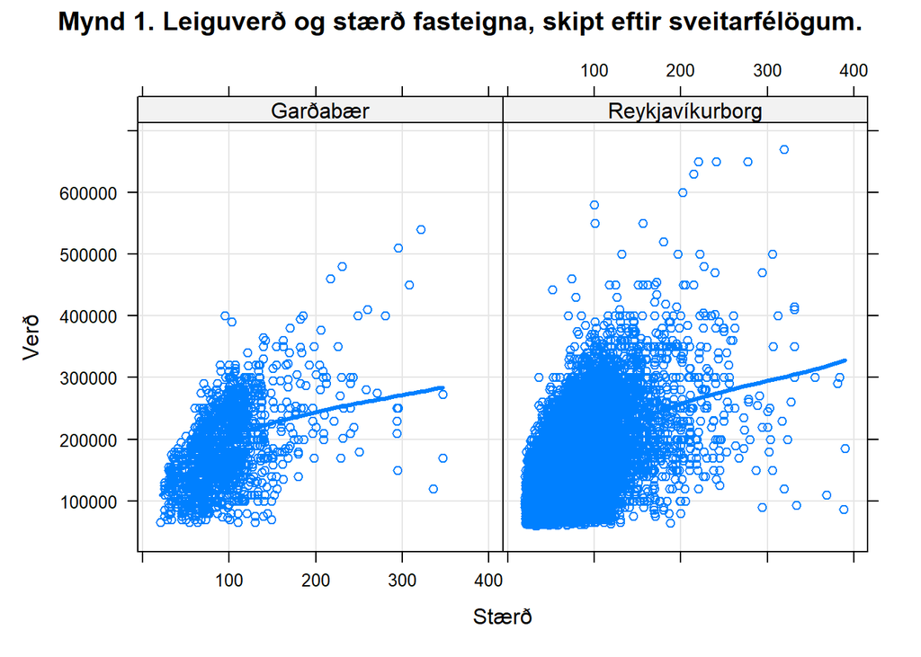

Á mynd 2 má sjá áhrif stærðar á verð, eftir sveitarfélögum. Við minni eignirnar er leiguverð í Reykjavíkurborg ódýrar. Línurnar skarast þó við um það bil 120 fermetra og þá verður leiguverð dýrara í Reykjavíkurborg.

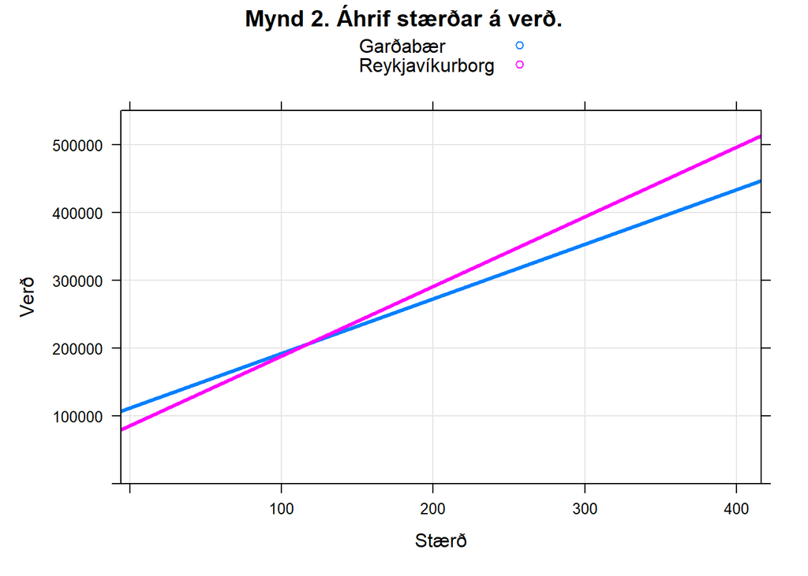

## *Líkan án samvirkni*

Búið var til líkan þar sem fylgibreytan var verð og frumbreyturnar stærð og sveitarfélag sem tók tvö gildi, Garðabær og Reykjavíkurborg. Í töflu 2 má sjá niðurstöður aðfallsgreiningarinnar.

```
##
## Call:
## lm(formula = verd ~ staerd + sveitarfelag, data = df_nytt)
##
## Residuals:
##     Min      1Q  Median      3Q     Max
## -392172  -39593   -2320   37229  392229
##
## Coefficients:
##                        Estimate Std. Error t value             Pr(>|t|)
## (Intercept)            86768.34     603.36 143.808 < 0.0000000000000002 ***
## staerd                  1010.03       7.66 131.866 < 0.0000000000000002 ***
## sveitarfelaggrb_vs_rvk  5742.72    1171.61   4.902          0.000000954 ***
## ---
## Signif. codes:  0 '***' 0.001 '**' 0.01 '*' 0.05 '.' 0.1 ' ' 1
##
## Residual standard error: 49320 on 48273 degrees of freedom
## Multiple R-squared:  0.2704, Adjusted R-squared:  0.2704
## F-statistic:  8946 on 2 and 48273 DF,  p-value: < 0.00000000000000022
```

Tafla 2. Niðurstöður marghliða aðfallsgreiningar án samvirkni: Líkan 1.

|  | Fasti | Hallastuðull | Staðalvilla | $t$-gildi | $p$-gildi |
| --- | --- | --- | --- | --- | --- |
| Skurðpunktur | (Intercept) | 86768.34 | 603.36 | 143.81 | 0 |
| Stærð | staerd | 1010.03 | 7.66 | 131.87 | 0 |
| Garðabær vs. Reykjavík | sveitarfelaggrb_vs_rvk | 5742.72 | 1171.61 | 4.90 | 0 |

Leiðrétt skýringarhlutfall var 27,04% og líkanið nær því yfir 27,04% af breytileika fylgibreytu. Það merkir að stærð og sveitarfélag náðu að útskýra 27,04% af breytileika á verðbreytingum á heildarleiguverði. Líkanið sem heild er marktækt; F(2, 48273) = 8946, *p* < 0,001.  
Hallastuðull stærðar var 1010,03 og marktækur með *p* < 0,001. Því er hægt að álykta að fyrir hvern fermetra þá hækkar verð eignar um 1010,03 krónur, þegar leiðrétt er fyrir áhrifum sveitarfélags. Öryggisbilið var [995,0149 ; 1025,040]. Hallastuðull sveitarfélags var 5742,72 og marktækur með *p* < 0,001. Verð eigna er því marktækt 5742 krónum hærri í Garðabæ samanborið við Reykjavíkurborg. Öryggisbilið var [3446,3392 ; 8039,095].

## *Líkan með samvirkni*

Smíðað var annað líkan út frá fyrra líkani þar sem bætt var við samvirkni. Niðurstöðurnar má sjá í töflu 3.

Tafla 3. Niðurstöður marghliða aðfallsgreiningar með samvirkni: Líkan 2.

|  | Fasti | Hallastuðull | Staðalvilla | $t$-gildi | $p$-gildi |
| --- | --- | --- | --- | --- | --- |
| Skurðpunktur | (Intercept) | 85584.19 | 623.14 | 137.34 | 0 |
| Stærð | staerd | 1026.28 | 7.95 | 129.05 | 0 |
| Garðabær vs. Reykjavík | sveitarfelaggrb_vs_rvk | 25988.99 | 2929.88 | 8.87 | 0 |
| Stærð:Garðabær vs. Reykjavík | staerd:sveitarfelaggrb_vs_rvk | -221.21 | 29.34 | -7.54 | 0 |

## *Samanburður líkananna*

Líkönin tvö voru borin saman og hér fyrir neðan má sjá niðurstöður samanburðarins. Fyrst eru mátgæði líkana með og án samvirkni athuguð, sjá töflu 4. Því næst eru hallastuðlar bornir saman, sjá töflu 5, og að lokum áhrif þess að fjarlægja breytu úr líkani ahuguð, fyrst fyrir líkan án samvirkni og næst fyrir líkan með samvirkni.

### *Mátgæði líkana*

Tafla 4. Mátgæði líkana.

[output not shown]

### *Samanburður hallatalna*

Í töflu 5 má sjá samanburð á líkönunum tveimur. Hallastuðull stærðar hækkar lítilega, eða um það bil 16, þegar samvirkni var bætt við líkanið en hallastuðull sveitarfélags hækkar töluvert, eða um 20,246. Skýringarhlutfallið helst óbreytt á milli líkana.

Tafla 5. Samanburður á hallastuðlum líkana.

|  | Líkan án samvirkni | Líkan með samvirkni |
| --- | --- | --- |
| (Intercept) | 86768.342 | 85584.192 |
| staerd | 1010.028 | 1026.275 |
| sveitarfelaggrb_vs_rvk | 5742.717 | 25988.992 |
| staerd:sveitarfelaggrb_vs_rvk | NA | -221.212 |